# R Notebook

### Plot PCA bi-plot

- Positively correlated variables are grouped together.
- Negatively correlated variables are positioned on opposite sides of the plot origin (opposed quadrants).
- The distance between variables and the origin measures the quality of the variables on the factor map. Variables that are away from the origin are well represented on the factor map.

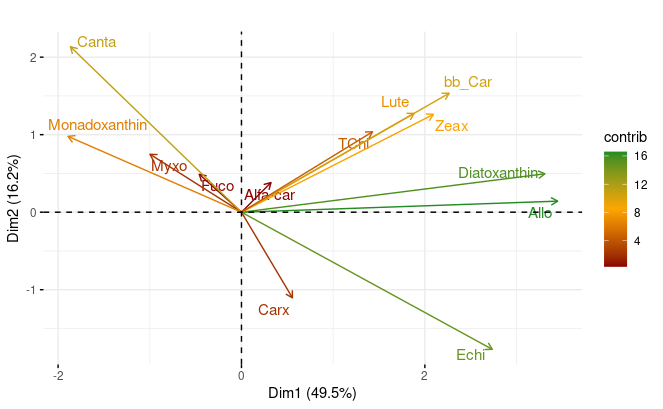

```r
#png(filename = /home/rstudio/work/holzmaar/data/fig/Figure1A.png, width = 680, height = 680, units = px, pointsize = 14, res=120)

# autochtonous <- text_grob(Autochtonous, size=13, face=bold, color= lightblue)
# allochtonous <- text_grob(Allochtonous, size=13, face=bold, color= lightblue)
# Organic <- text_grob(Organic matter\nand redox, size=13, face=bold, color= grey,rot = 90)
# Mineral <- text_grob(Minerals, size=13, face=bold, color= grey, rot=90)

#PCA_clr <-
  fviz_pca_var(res.pca, col.var="contrib", axes = c(1,2), clip = ("off"),
             gradient.cols = c("darkred", "orange", "forestgreen"),
             repel = TRUE, title = " ")#+
```

```r
        #theme(plot.margin = unit(c(1,1,2,1), lines)) +
          # annotation_custom(allochtonous,xmin=-0.4,xmax=-0.4,ymin=-0.7,ymax=-0.7) +
          # annotation_custom(autochtonous,xmin=0.7,xmax=0.7,ymin=-0.7,ymax=-0.7) +
          # annotation_custom(Organic,xmin=-0.7, xmax=-0.7,ymin=0.4,ymax=0.4) +
          # annotation_custom(Mineral,xmin=-0.7,xmax=-0.7,ymin=-0.4,ymax=-0.4)
  #coord_cartesian(clip = off)

#dev.off()
```

### Correlation of the variables with the principle components

We can further explore the correlation of the variable with the PC axis to get better understanding of what variables are exploring each axis.

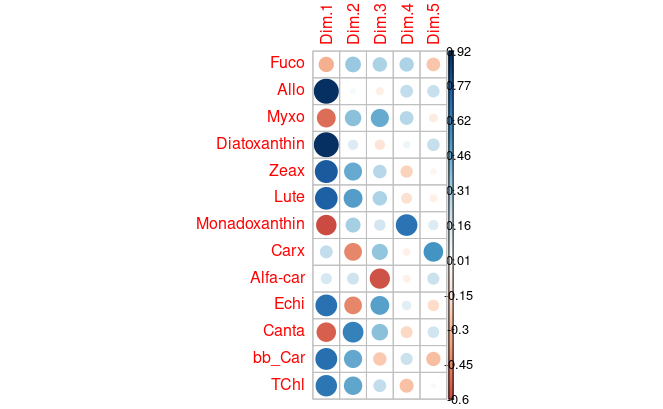

```r
corrplot(var$cor, is.corr=FALSE)
```

### Plot the variables contribution to PCx

Further to statistically constrain/explore the contribution of the variable to the PC axis we plot the PC axis histograms.

#### Contributions of variables to PC1

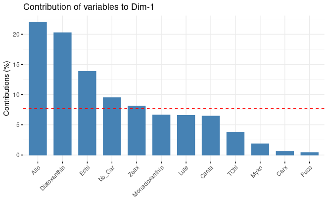

```r
fviz_contrib(res.pca, choice = "var", axes = 1, top = 12)
```

#### Contributions of variables to PC2

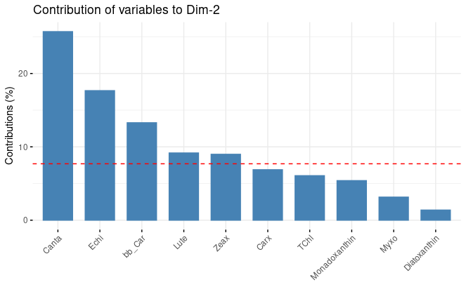

```r
fviz_contrib(res.pca, choice = "var", axes = 2, top = 10)
```

#### Contributions of variables to PC3

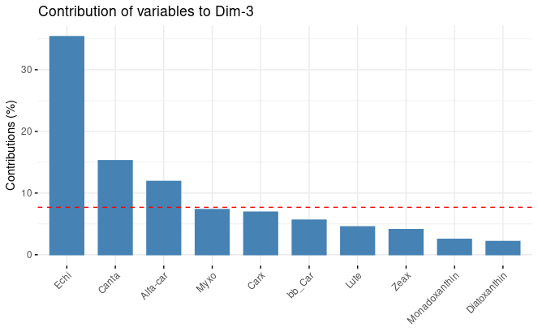

```r
fviz_contrib(res.pca, choice ="var", axes = 3, top = 10)
```

## PCA on alr and z-scored

```r
res.pca_scaled <- PCA(t(alr),  graph = FALSE, scale = 1) # in case one wants to scale the data using z-score
varS<- get_pca_var(res.pca_scaled)
get_eig(res.pca_scaled)
```

```
        eigenvalue variance.percent cumulative.variance.percent
Dim.1  5.469417330      42.07244100                    42.07244
Dim.2  2.401582003      18.47370772                    60.54615
Dim.3  1.477684907      11.36680698                    71.91296
Dim.4  0.946850977       7.28346905                    79.19642
Dim.5  0.840280260       6.46369431                    85.66012
Dim.6  0.599873070       4.61440823                    90.27453
Dim.7  0.464316745       3.57166727                    93.84619
Dim.8  0.310779861       2.39061431                    96.23681
Dim.9  0.193644771       1.48957516                    97.72638
Dim.10 0.132280556       1.01754274                    98.74393
Dim.11 0.098375690       0.75673608                    99.50066
Dim.12 0.061196439       0.47074184                    99.97140
Dim.13 0.003717391       0.02859531                   100.00000
```

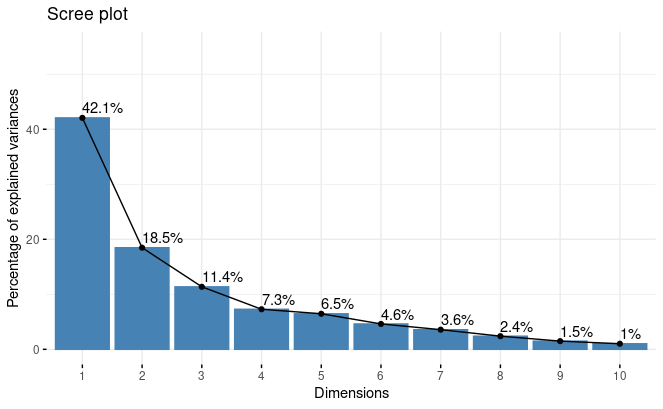

```r
#png(filename = XRF_HSI_PCA_explanatory_power.png, width = 800, height = 500, units = px, pointsize = 12)
fviz_screeplot(res.pca_scaled, addlabels = TRUE, ylim = c(0, 55))
```

We can see that the PC1 axis has now lower percentage of the explained variances (42%), which brought more explained variance to the PC2 (18). In this way we get more explanatory power on PC2 which means for us that we can identify more than the one dominant process explaining the data variance (as it was in the first PCA of non-scaled data). Thus, we get more explanatory PCA when z-scoring the data which helps to our data interpretation.

### PCA on scaled data

- Positively correlated variables are grouped together.
- Negatively correlated variables are positioned on opposite sides of the plot origin (opposed quadrants).
- The distance between variables and the origin measures the quality of the variables on the factor map. Variables that are away from the origin are well represented on the factor map.

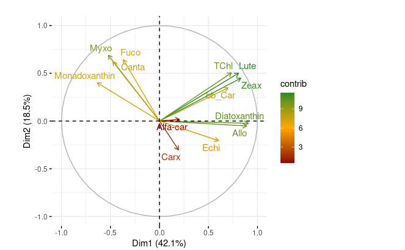

```r
# autochtonous <- text_grob(Autochtonous, size=13, face=bold, color= lightblue)
# allochtonous <- text_grob(Allochtonous, size=13, face=bold, color= lightblue)
# Organic <- text_grob(Organic matter\nand redox, size=13, face=bold, color= grey,rot = 90)
# Mineral <- text_grob(Minerals, size=13, face=bold, color= grey, rot=90)

#PCA_clr_scaled <-
  fviz_pca_var(res.pca_scaled, col.var="contrib", axes = c(1,2),
             gradient.cols = c("darkred", "orange", "forestgreen"),
             repel = TRUE, title = "" )+
   theme(plot.margin = unit(c(0.1,8,0.1,2), "lines")) +
          # annotation_custom(autochtonous,xmin=-.5,xmax=-0.5,ymin=-1,ymax=-1) +
          # annotation_custom(allochtonous,xmin=0.5,xmax=0.5,ymin=-1,ymax=-1) +
          # annotation_custom(Organic,xmin=-1, xmax=-1,ymin=0.7,ymax=0.7) +
          # annotation_custom(Mineral,xmin=-1,xmax=-1,ymin=-0.5,ymax=-0.5)+
  coord_cartesian(clip = "off")
```

### Correlation of the variables with the principle components - scaled

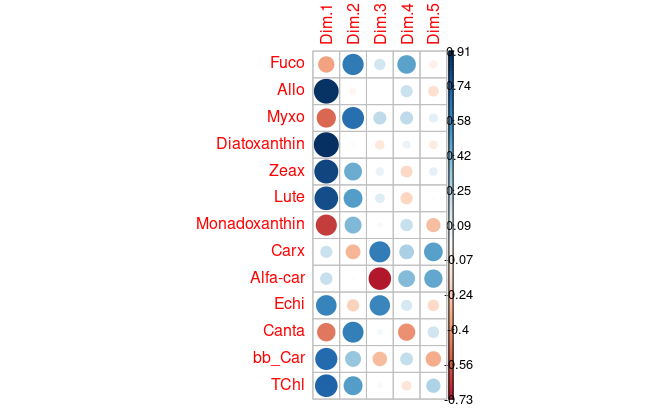

```r
corrplot(varS$cor, is.corr=FALSE)
```

### Plot the variables contribution to PCx

#### Contributions of variables to PC1

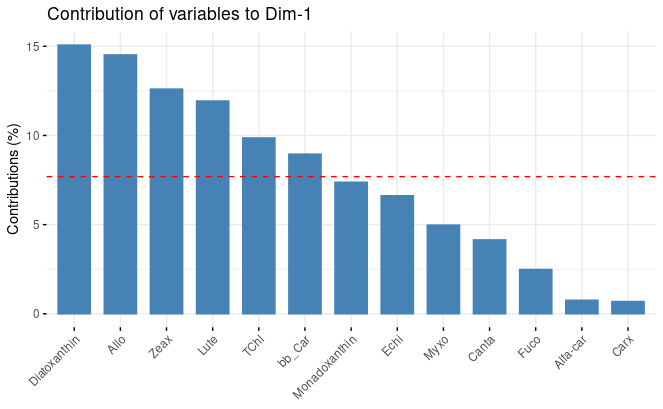

```r
fviz_contrib(res.pca_scaled, choice = "var", axes = 1, top = 15)
```

#### Contributions of variables to PC2

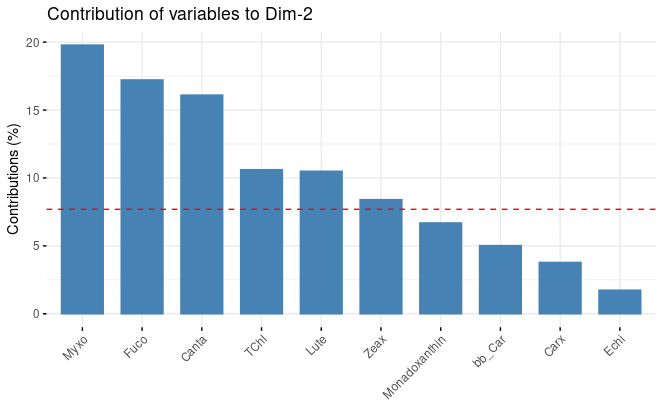

```r
fviz_contrib(res.pca_scaled, choice = "var", axes = 2, top = 10)
```

#### Contributions of variables to PC3

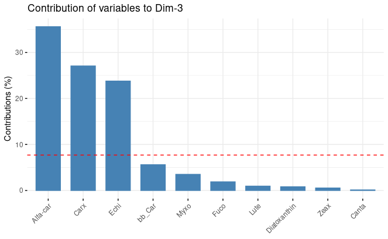

```r
fviz_contrib(res.pca_scaled, choice = "var", axes = 3, top = 10)
```

## PCA on alr data with hierarchical unconstrained clusters

For further data exploration and explanation we combine the results of clustering with the PCA bi-plots. In this way, we see what the important variables defining the specific lithotypes (the clusters).

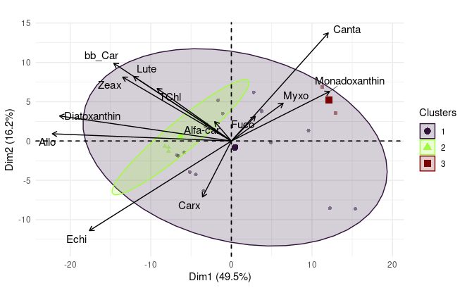

```r
res.pca <- prcomp(t(alr), scale =F)
#res.pca <- PCA(df, scale = 0)
#var <- get_pca_var(res.pca)
#get_eig(res.pca)

# autochtonous <- text_grob(Autochtonous, size=13, face=bold, color= lightblue)
# allochtonous <- text_grob(Allochtonous, size=13, face=bold, color= lightblue)
# Organic <- text_grob(Organic matter\nand redox, size=13, face=bold, color= grey,rot = 90)
# Mineral <- text_grob(Minerals, size=13, face=bold, color= grey, rot=90)


b_clr <- fviz_pca_biplot(res.pca, label="var", axes = c(1,2), repel = TRUE,
                     title =" " , col.var = "black", #xlab = PC1 (55.3%), ylab=PC2 (10.2%),
                     alpha.var = 1, alpha.ind = 0.5, habillage=PCA_pig$Hcluster,
               addEllipses=TRUE, ellipse.level=0.95, ellipse.alpha = 0.2) +
  labs(color = "Clusters", shape ="Clusters", fill = "Clusters")+
  # annotation_custom(autochtonous,xmin=-3,xmax=-3,ymin=-4,ymax=-4) +
  # annotation_custom(allochtonous,xmin=3,xmax=3,ymin=-4,ymax=-4) +
  # annotation_custom(Organic,xmin=-5, xmax=-5,ymin=-2,ymax=-2) +
  # annotation_custom(Mineral,xmin=-5,xmax=-5,ymin=3,ymax=3)+
  theme(plot.margin = unit(c(0.1,8,0.1,2), "lines"))#+
   #coord_cartesian(xlim = c(-5, 5), ylim = c(-4, 4), clip = "off")

b_clr + scale_color_viridis_d(option ="H") +
  scale_fill_viridis_d(option = "H")+
     theme_minimal()
```

## PCA on alr z-scored data with hierarchical unconstrained clusters

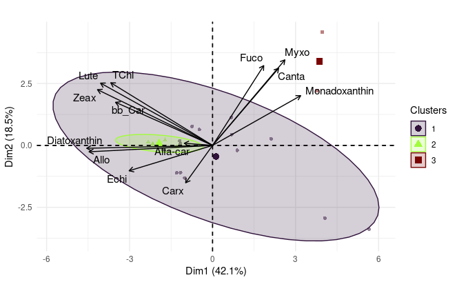

```r
res.pca_scaled <- prcomp(t(alr), scale =T)

# autochtonous <- text_grob(Autochtonous, size=13, face=bold, color= lightblue)
# allochtonous <- text_grob(Allochtonous, size=13, face=bold, color= lightblue)
# Organic <- text_grob(Organic matter\nand redox, size=13, face=bold, color= grey,rot = 90)
# Mineral <- text_grob(Minerals, size=13, face=bold, color= grey, rot=90)


b_z <- fviz_pca_biplot(res.pca_scaled, label="var", axes = c(1,2), repel = TRUE,
                     title =" " , col.var = "black", #xlab = PC1 (45.3%), ylab=PC2 (11.5%),
                     alpha.var = 1, alpha.ind = 0.5, habillage=PCA_pig$Hcluster,
               #cluster_CONISS, #K_means_cluster, Hcluster
               addEllipses=TRUE, ellipse.level=0.95, ellipse.alpha = 0.2) +
  labs(color = "Clusters", shape ="Clusters", fill = "Clusters")+
  # annotation_custom(autochtonous,xmin=-5,xmax=-5,ymin=-6,ymax=-6) +
  # annotation_custom(allochtonous,xmin=5,xmax=5,ymin=-6,ymax=-6) +
  # annotation_custom(Organic,xmin=-8, xmax=-8,ymin=-4,ymax=-4) +
  # annotation_custom(Mineral,xmin=-8,xmax=-8,ymin=4,ymax=4)+
  theme(plot.margin = unit(c(0.1,8,0.1,2), "lines"))#+
  #coord_cartesian(xlim = c(-8, 8), ylim = c(-6, 6), clip = "off")

b_z + scale_color_viridis_d(option ="H") +
  scale_fill_viridis_d(option = "H")+
     theme_minimal()
```

```r
NA
NA
```

Extracting the 4 PCs

One the PCA axis are well explored and the phenomena responsible to the data variation are explained, the PCA axis can be used as the reduced dataset replacing the original variables when representing the given/selected phenomena. Thus, we extract the PC axis scores and save them along with our data for further plotting or data analysis.

```r
#summary(res.pca)
res.pca <- prcomp(t(alr), scale. =T, rank. = 4) #center = T,
summary(res.pca)
```

```
Importance of first k=4 (out of 13) components:
                          PC1    PC2    PC3     PC4
Standard deviation     2.3387 1.5497 1.2156 0.97306
Proportion of Variance 0.4207 0.1847 0.1137 0.07283
Cumulative Proportion  0.4207 0.6055 0.7191 0.79196
```

Attaching the PC scores to the dataset

```r
# Extract principal component scores (first two components)
pc_scores <- res.pca$x  # Selects columns 1 and 2 for the first two PCs

# Extract loadings for all principal components
pc_loadings <- res.pca$rotation

df_PC <- bind_cols(PCA_pig, pc_scores)

write.xlsx(df_PC, "~/Pig_clustered_PC.xlsx", rowNames = FALSE, col_type ="numeric")
```

## Trajectory plots

The sedimentary data can be preceived as time-series data as the process of settlement is happening though time. Thus, while using the CONISS clustering, which groups the sediment data with respect to the depth/time variable, the PC axis can be used to plot the data and be able to track the chronological development of the variables represented by the PC scores. These plots are here called trajectory and they represent the evolution of the sediment composition though depth/time.

```r
df_PC <- read.xlsx("~/Pig_clustered_PC.xlsx")
depth_m <- as.data.frame(df_PC$`Composite depth`)

# df_PC <- df_PC%>% mutate(PZn = case_when(PolZ == "Pleniglacial" ~ "1",
#                            PolZ == "Bølling" ~ "2",
#                            PolZ == "Allerød" ~ "3",
#                            PolZ == "YoungerDryas" ~ "4")
#    )
```

```r
# #plot(df_PC$PC1, df_PC$PC2, type= l, text = df_PC$comp_depth_mm)
# End <- df_PC %>% # last trading day
#   slice_max(df_PC$Composite.depth)
#
# Start <- df_PC %>% # first trading day
#   slice_min(df_PC$Composite.depth)
#   #slice(which.min(depth_m))
#
#
# s <- ggplot(df_PC, aes(PC1, PC2)) +
#   geom_point(aes(colour = factor(PZn),  shape = factor(PZn), alpha = 0.3))+
#   labs(alpha = "Trajectory")+
#  #geom_line()
#   geom_path(alpha=0.3, col = "black", arrow = arrow(type = "closed", length = unit(0.25, "inches"), ends = "first")) +
#   labs(colour = "PZn", shape = "PZn") +
# # last trading day - round mark, annotation below
#   geom_point(data = Start, aes(x = PC1, y = PC2), col = "green", shape = 21, fill = "green", size = 2, stroke = 1.7) +
#   geom_text(data = Start, aes(x = PC1, y = PC2, label = sprintf("%0.0f", round(Start$comp_depth_mm, digits = 0))), size = 4, vjust = 2.5) +
#   # first trading day - round mark, annotation above
#   geom_point(data = End, aes(x = PC1, y = PC2), col = "red", shape = 21, fill = "red", size = 2, stroke = 1.7) +
#   geom_text(data = End, aes(x = PC1, y = PC2, label = sprintf("%0.0f", round(End$comp_depth_mm, digits = 0))), size = 4, face= "bold", vjust = -1.5)
#
# #png(filename = /home/rstudio/work/holzmaar/data/fig/Figure1C.png, width = 680, height = 600, units = px, pointsize = 14, res=120)
#
# traj <- s + scale_color_brewer(palette="Dark2", labels = c("Younger Dryas", "Allerød", "Bølling-Allerød", "Pleniglacial"))+
#   scale_shape_discrete(labels = c("Younger Dryas", "Allerød", "Bølling-Allerød", "Pleniglacial")) +#Paired
#      theme_minimal()+
#   # annotation_custom(autochtonous,xmin=-4,xmax=-4,ymin=-6,ymax=-6) +
#   # annotation_custom(allochtonous,xmin=5,xmax=5,ymin=-6,ymax=-6) +
#   # annotation_custom(Organic,xmin=-7, xmax=-7,ymin=-3,ymax=-3) +
#   # annotation_custom(Mineral,xmin=-7,xmax=-7,ymin=5,ymax=5)+
#  # theme(plot.margin = unit(c(0.1,8,0.1,2), lines))+
#   coord_cartesian(xlim = c(-10, 10), ylim = c(-8, 8), clip = "off")
#
# #dev.off()
# traj
```

PCAs are not really explanatory, thus we try to apply multidimensional scaling (MDS) instead and correlation matrix or heat maps can be better approach.

# 04_MDS

```r
# mds_pig <- cmdscale(dist(alr), k=3)
# mds_df <- as.data.frame(mds_pig)
# df_PC <- bind_cols(df_PC, mds_df)
```

```r
# plot(mds_pig[, 1], mds_pig[, 2])
# points(mds_pig[, 1], mds_pig[, 2], pch =21, bg = df_PC$Hcluster)# here the color of the datapoints can be changed to show any of the made clusterings or the pollen zones
```

For the MSD visualization and interpretability, we use the pollen zones as the shape and color of our datapoints.

```r
# ggscatter(df_PC, x = "V1", y = "V2",
#           color = "PZn", shape = "PZn", fill = "PZn",
#           palette = "jco",
#           size = 3,
#           ellipse = TRUE,
#           ellipse.type = "convex",
#           title = " ",
#           xlab = "MDS Dimension 1",
#           ylab = "MDS Dimension 2") +
#     labs(color = "Pollen Zones", shape ="Pollen Zones", fill = "Pollen Zones") +
#   scale_color_discrete(name = 'Pollen Zones', labels = c("Pleniglacial","Bølling","Allerød","Younder Dryas"))+
#   scale_fill_discrete(name = 'Pollen Zones', labels = c("Pleniglacial","Bølling","Allerød","Younder Dryas"))+
#   scale_shape_discrete(name = 'Pollen Zones', labels = c("Pleniglacial","Bølling","Allerød","Younder Dryas"))
#   #geom_text_repel(aes(label = species), box.padding = 0.5)
```

```r
# colors <- c("red", "blue", "pink")
# colors <- colors[as.numeric(df_PC$PZn)]
# scatterplot3d(mds_pig[,1:3], pch = 16,
#               xlab = "",
#               ylab = "",
#               zlab = "",
#               color=colors)
```

# 05_Non-metric multidimensional scaling (NMDS)

Non-metric Multidimensional Scaling (NMDS) is a great tool for ecologists to understand community assemblages and identify their influencing factors. We use a data frame/matrix with relative abundances of different pigments in different time periods. Each pigment abundance in the time is an axis and each axis is a dimension. NMDS summarise all of that information into a 2-dimensional representation, showing the differences in pigment community composition. It tries to represent the original position of a community within a multidimensional space as accurately as possible while also minimising the number of dimensions to easily plot and visualise.

## Relative abundance of pigments (%)

Converting the absolute concentrations of pigments to relative %.

```r
# community <- df_PC[,2:22]
# commper <- adorn_percentages(community, denominator = "row", na.rm = TRUE, 2:21)
# comPer <- commper[2:21]*100
```

Transforming the data frame into a matrix and performing the NMDS.

```r
# ComMatrix <- as.matrix(comPer)
#
# inv.NMDS <- metaMDS(ComMatrix, distance = "bray", k = 3, autotransform = TRUE, trymax=100)
#
# # check stress value
# inv.NMDS$stress # ideally stress value is < 0.2
#
# plot(inv.NMDS)
#
# #ordiplot(inv.NMDS, type = "n") # create blank ordination plot
# orditorp(inv.NMDS, display = "species", col="red", air = 0.4) # add species (orders in this case) names in red
# orditorp(inv.NMDS, display = "sites", cex = 1.25, air = 0.4) # add site numbers in black
```

```r
# #png("~/work/holzmaar/figs/NMDS.png", width=6, height=5, units = "in", res = 300)
# ordiplot(inv.NMDS) # plot shows communities (circles) and species (crosses)
# orditorp(inv.NMDS, display = "species", col="red", air = 0.4)
# orditorp(inv.NMDS, display = "sites", cex = 0.7, air = 0.4)
# ordiellipse(inv.NMDS, df_PC$PZn, label = FALSE,
#             col=c("dodgerblue", "tomato2", "tomato4", "deepskyblue"),
#             draw = "polygon", alpha=120) # adding ellipses to the plot, grouping by distance (inverts$Distance)
# legend("topleft", title="Pollen Zone", c("Pleniglacial","Bølling","Allerød","Younger Dryas"),
#        fill=c("dodgerblue", "tomato2", "tomato4",
#                                    "deepskyblue"), horiz=FALSE, cex=.9) # adding a legend
# #dev.off()
```

```r
# nmds.scores <- as.data.frame(scores(inv.NMDS)$sites)
#
# nmds.scores <- nmds.scores %>%
#   mutate(Time = as.factor(df_PC$PZn))
#
#
# # create ggplot
# (inv_NMDS_plot <- ggplot(data = nmds.scores, aes(NMDS1, NMDS2)) +
# # adding different colours and shapes for points at different distances
#     geom_point(aes(color = Time, shape = Time)) +
# # adding covariance ellipses according to distance # use size argument if ggplot2 < v. 3.4.0
#    # geom_path(data=nmds.scores, aes(x=NMDS1, y=NMDS2, colour=Time), linewidth=1) +
# # removes lines from legend
#     guides(color = guide_legend(override.aes = list(linetype=c(NA,NA,NA,NA)))) +
#     theme_bw() +
#     theme(panel.grid = element_blank()) +
# # legend title
#     scale_color_manual(name = "Pollen Zone",
#     # adjusting legend labels and colour
#             labels = c("Pleniglacial","Bølling","Allerød","Younger Dryas"),
#             values = c("dodgerblue", "tomato2", "tomato4", "deepskyblue")) +
#     scale_shape_manual("Pollen Zone",
#             labels = c("Pleniglacial","Bølling","Allerød","Younger Dryas"),
#             values = c(17, 15, 3, 7))) # customising shapes
# # save plot
# #ggsave(filename = "~/work/holzmaar/figs/NMDSPaths.png", inv_NMDS_plot, device = "png")
```

# 06_Correlation based heatmaps

To best present the pigment data, we need to decrees their dimensionality. We tried to use PCA, where we saw groups of pigments representing the community composition, but to visualize these communities on a time axis, we opt for correlation based heat maps.

```r
pig_prod <- read_excel("~/SourceData/Pig.xlsx", sheet = "pig_prod")
pig_prod_df <- as.data.frame(pig_prod)
rownames(pig_prod_df) <- pig_prod_df[,2]
pig_prod_df
```

|  | ID | pigment | producer | alternative |
| --- | --- | --- | --- | --- |
| Fucoxanthin | Fuco | Fucoxanthin | Silicifiers | Diatoms, Chysophytes |
| Alloxantin | Allo | Alloxantin | Cryptophytes | NA |
| Myxoxantophyll | Myxo | Myxoxantophyll | Cyanobacteria | NA |
| Diatoxanthin | Diatoxanthin | Diatoxanthin | Silicifiers | Diatoms, Dinoflagellate, Euglena |
| Zeaxantin | Zeax | Zeaxantin | Cyanobacteria | Red algae, Green algae, Euglena, Chrysophytes, Brown algae |
| Lutein | Lute | Lutein | Green algae | Red algae |
| Monadoxanthin | Mona | Monadoxanthin | Cryptophytes | NA |
| misterious Carotenoids | Carxx | misterious Carotenoids | Green algae | NA |
| a_Carotene | Alfa-car | a_Carotene | Green algae | NA |
| Echinenone | Echi | Echinenone | Cyanobacteria | Green algae, Diatoms |

[output cut: 3 more lines]

```r
col_names <- pig_prod_df[,2]
```

In case the scirpt starts here, we load all the data from the code above

```r
df_PC <- read.xlsx("~/Pig_clustered_PC.xlsx")
depth_m <- as.data.frame(df_PC$Composite.depth)

# df_PC <- df_PC%>% mutate(PZn = case_when(PolZ == "Pleniglacial" ~ "1",
#                            PolZ == "Bølling" ~ "2",
#                            PolZ == "Allerød" ~ "3",
#                            PolZ == "YoungerDryas" ~ "4")
#    )
```

```r
alr_safe <- read.xlsx("~/pig_alr.xlsx")
```

```r
pig_prod_df <- pig_prod_df[,-1]
annotation_col = pig_prod_df[2]
```

```r
# depth_mat <- as.data.frame(select(df_PC,1, 23, 2))
#
# rownames(depth_mat) <- depth_mat[,1]
# depth_mat <- depth_mat[,-1]
# annotation_row = depth_mat[1]
```

```r
new_names <- alr_safe[,1]

alr_mat <- as.matrix(alr_safe[,2:14])
rownames(alr_mat) <- new_names
colnames(alr_mat) <- col_names

alr_scaled<- scale(alr_mat)
```

In case one doesn’t want to run the hear maps on the alr scaled data, here is the matrix of the raw peak areas

```r
pig_filled_ID <- as.matrix(pig_filled)
rownames(pig_filled_ID) <- new_names
colnames(pig_filled_ID) <- col_names
```

```r
ann_colors = list(
   producer = c(Cryptophytes = "darkorange3", Cyanobacteria ="royalblue2", `Green algae` = "green4", # `Green sulphur bacteria` = "greenyellow", `Purple non-sulphur bacteria`= "orchid2", `Purple sulphur bacteria` = "purple2", `Red blooming algae` = "red4",
                Silicifiers= "lightskyblue"))#,
#     PolZ = c(Pleniglacial = "dodgerblue", Bølling = "tomato2", Allerød = "tomato4", `YoungerDryas` = "deepskyblue")) #`Lachersee tephra` = "gray29"
#   #  GeneClass = c(Path1 = "#7570B3", Path2 = "#E7298A", Path3 = "#66A61E")
# # ,

#Both dimension clustering
png(filename = "~/figs/heatmap_corr_clustered.png", width = 1200, height = 800, units = "px", pointsize = 18)
pheatmap(alr_scaled, show_rownames=T,show_colnames=T,
         annotation_col= annotation_col, #annotation_row = annotation_row,
         annotation_colors = ann_colors,
         scale = "none",clustering_method="ward.D2", #cluster_rows = F,
         clustering_distance_cols="correlation", clustering_distance_rows = "euclidean",
         cutree_rows = 3,
         cutree_cols = 4, treeheight_row = 50,
         treeheight_col = 50, color = colorRampPalette(c("lightskyblue1","darkseagreen1","lightgreen","yellow", "orange", "red", "purple"))(15))
dev.off()
```

```r
# Only pigment clustering
png(filename = "~/figs/Heatmap_corr.png", width = 1200, height = 800, units = "px", pointsize = 18)
```

```r
obj <- pheatmap(alr_scaled, show_rownames=T,show_colnames=T,
         annotation_col=annotation_col, #nnotation_row = annotation_row,
         annotation_colors = ann_colors,
         scale = "none", #clustering_method="ward.D2",
         cluster_rows = F,
         clustering_distance_cols="euclidean", #clustering_distance_rows = "euclidean",
        # cutree_rows = 5,
         cutree_cols = 3, #treeheight_row = 50,
         treeheight_col = 50, color = colorRampPalette(c("lightskyblue1","darkseagreen1","lightgreen","yellow", "orange", "red", "purple"))(15))
dev.off()
```

Extract the clusters, make mean curve and use for a line plot

```r
obj$tree_row
```

```
[1] NA
```

```r
obj$tree_col
```

```
Call:
hclust(d = d, method = method)

Cluster method   : complete
Distance         : euclidean
Number of objects: 13
```

```r
PigClust <- cutree(obj$tree_col, k = 3) #fill in the number of observations (rows) and number of clusters acooriding to the dendrogram
# df_clustered <- bind_cols(df_clustered, clustercut)
# colnames(df_clustered)[29] <- 'order' # change the column number based on your dataset size
# colnames(df_clustered)[30] <- 'Hcluster' # change the column number based on your dataset size

PigClust <- as.data.frame(t(PigClust))

alr_scaled <- as.data.frame(alr_scaled)
alr_scaledB<- rbind("PigClust" = PigClust , alr_scaled)
```

```r
df1 <- as.data.frame(t(alr_scaledB))

selection1 <- as.data.frame(t(df1[df1$PigClust == "1", ]))
selection2 <- as.data.frame(t(df1[df1$PigClust == "2", ]))
selection3 <- as.data.frame(t(df1[df1$PigClust == "3", ]))
```

```r
alr_scaled$C1 <- rowMeans(selection1[2:24,])
alr_scaled$C2 <- rowMeans(selection2[2:24,])
alr_scaled$C3 <- rowMeans(selection3[2:24,])


alr_scaled_clust<- bind_cols("depth" = PCA_pig$`Composite depth`, #"age" = PCA_pig$mean_VT22
                             alr_scaled)

write.xlsx(alr_scaled_clust, "~/pig_alr_clust.xlsx", rowNames = FALSE, col_type ="numeric")
```